# [UzunAI](https://uzunai.vercel.app/) Only Latest Portfolio

[Github](https://github.com/UzunDemir) | [linkedin](https://www.linkedin.com/in/uzundemir/) | [site](https://uzundemir.github.io/) | uzunvitt@gmail.com | +37367164777

## 1) 🏗️ ML Project Template – Production-Ready Machine Learning Platform by Uzun Demir

[figure not shown]

## 📋 Overview

A **distributed microservices platform** built with FastAPI and Docker Compose. Each service has isolated dependencies, enabling independent scaling and development. The platform demonstrates service discovery, inter-service communication, and containerized deployment.

## 🏛️ Architecture

```
┌─────────────────────────────────────────────────────────────┐
│                     Docker Network                          │
│  ┌──────────────┐  ┌──────────────┐  ┌──────────────┐       │
│  │ API Gateway  │  │ ML Service   │  │ User Service │       │
│  │   :8000      │◄─┤   :8000      │  │   :8000      │       │
│  └──────────────┘  └──────────────┘  └──────────────┘       │
│         │                                                   │
│         └──────────► Order Service (future)                 │
└─────────────────────────────────────────────────────────────┘
```

## 🚀 Services & Dependencies

| Service | Dependencies | Purpose |
| --- | --- | --- |
| **API Gateway** | fastapi, uvicorn, httpx | Entry point, request routing |
| **ML Service** | fastapi, uvicorn, httpx, pandas, scikit-learn | AI/ML predictions |
| **User Service** | fastapi, uvicorn, sqlalchemy | User management |
| **Order Service** | fastapi, uvicorn | Order processing |

## 📁 Project Structure

```
uzun-platform/
├── compose.yml                    # Docker Compose configuration
├── platform/
│   ├── api-gateway/               # Entry point service
│   │   ├── main.py
│   │   ├── Dockerfile
│   │   └── requirements.txt       # httpx only
│   │
│   ├── services/
│   │   ├── ml-service/            # AI/ML microservice
│   │   │   ├── main.py
│   │   │   ├── Dockerfile
│   │   │   └── requirements.txt   # pandas, scikit-learn
│   │   │
│   │   ├── user-service/          # User management
│   │   │   └── requirements.txt   # sqlalchemy
│   │   │
│   │   └── order-service/         # Order processing
│   │       └── requirements.txt   # minimal
│   │
│   ├── shared/
│   │   └── event_bus/             # Shared utilities
│   │       └── __init__.py
│   │
│   └── notebooks/                 # Research & experimentation
│       └── research.ipynb
```

## 🛠️ Installation & Setup

### Prerequisites

- Docker Engine 20.10+
- Docker Compose 2.0+
- Python 3.11 (for local development)

### Quick Start

```
# Clone repository
git clone https://github.com/UzunDemir/platform.git
cd platform

# Run the setup script
python setup_platform.py

# Or run Docker Compose directly
docker compose up --build -d
```

### Manual Setup

```
# Build all services
docker compose build

# Start all services
docker compose up -d

# View logs
docker compose logs -f

# Stop all services
docker compose down
```

## 🔗 Service Endpoints

| Service | Internal URL | External Access |
| --- | --- | --- |
| API Gateway | http://api-gateway:8000 | http://localhost:8000 |
| ML Service | http://ml-service:8000 | Not exposed directly |
| User Service | http://user-service:8000 | Not exposed directly |

### API Endpoints

```
# Gateway health check
curl http://localhost:8000/

# Test ML service communication
curl http://localhost:8000/check-ml

# ML service direct (if needed)
curl http://localhost:8001/  # Not exposed by default

# ML prediction (POST)
curl -X POST http://localhost:8000/predict \
  -H "Content-Type: application/json" \
  -d '{"data": "example"}'
```

## 🧪 Testing Inter-Service Communication

```
# Via API Gateway
import httpx

response = httpx.get("http://localhost:8000/check-ml")
print(response.json())
# Output: {
#   "gateway_response": "ML Contacted",
#   "ml_data": {"status": "AI Brain Active", ...}
# }
```

## 📦 Dependency Isolation Strategy

Each service gets only the libraries it needs:

```
# REQUIREMENTS_MAP controls dependencies per service
REQUIREMENTS_MAP = {
    "api-gateway": "fastapi\nuvicorn\nhttpx\n",        # Lightweight
    "ml-service": "fastapi\nuvicorn\nhttpx\npandas\nscikit-learn\n",  # Heavy
    "user-service": "fastapi\nuvicorn\nsqlalchemy\n",  # DB tools
    "default": "fastapi\nuvicorn\n"                    # Minimal
}
```

## 🐳 Docker Configuration

### Dockerfile (All Services)

```
FROM python:3.11-slim
WORKDIR /app
COPY requirements.txt .
RUN pip install --no-cache-dir -r requirements.txt
COPY . .
CMD ["uvicorn", "main:app", "--host", "0.0.0.0", "--port", "8000"]
```

### Docker Compose Network

```
services:
  api-gateway:
    build: ./platform/api-gateway
    ports: ["8000:8000"]
    networks: [ud-network]

  ml-service:
    build: ./platform/services/ml-service
    networks: [ud-network]  # Internal only

networks:
  ud-network:
    driver: bridge
```

## 🔧 Development

### Local Development (without Docker)

```
# Install dependencies for specific service
cd platform/services/ml-service
pip install -r requirements.txt

# Run service locally
uvicorn main:app --reload --port 8001
```

### Add New Service

1. Create directory in `platform/services/`
2. Add `main.py`, `Dockerfile`, `requirements.txt`
3. Update `STRUCTURE` dict in `setup_platform.py`
4. Add service to `compose.yml`

## 📊 Performance Considerations

| Service | Image Size | Build Time | Memory Usage |
| --- | --- | --- | --- |
| API Gateway | ~150 MB | ~30s | ~100 MB |
| ML Service | ~250 MB | ~60s | ~300 MB |
| User Service | ~150 MB | ~30s | ~120 MB |

## 🚦 Troubleshooting

### Common Issues

**Service can't reach another service:**

```
# Check if services are running
docker compose ps

# Check network connectivity
docker exec -it platform-api-gateway-1 ping ml-service
```

**Dependency installation fails:**

```
# Rebuild with no cache
docker compose build --no-cache

# Check requirements.txt content
docker exec -it platform-ml-service-1 cat requirements.txt
```

**Port conflicts:**

```
# Change port mapping in compose.yml
ports: ["8000:8000"]  # [HOST:CONTAINER]
```

## 🔒 Security Notes

- Services communicate internally via Docker network
- Only API Gateway exposes ports to host
- No authentication implemented (add for production)
- Consider adding rate limiting and API keys

## 🎯 Future Enhancements

- Add service discovery (Consul/etcd)
- Implement API authentication (JWT)
- Add load balancer (Nginx/Traefik)
- Centralized logging (ELK stack)
- Distributed tracing (Jaeger)
- Message queue (RabbitMQ/Kafka)
- Database migrations (Alembic)
- Health check endpoints
- Metrics collection (Prometheus)

## 📄 License

MIT License – free to use, modify, and distribute.

## 👨‍💻 Author

**Uzun Demir**

- GitHub: [@UzunDemir](https://github.com/UzunDemir)
- Telegram: [@ai_stack](https://t.me/ai_stack)
- LinkedIn: [Uzun Demir](https://www.linkedin.com/in/uzundemir/)

⭐ **Star this repo** if you find the microservices architecture useful!

*Built with 🐳 Docker and ⚡ FastAPI*

## 2) 🚀 AI Digital Office — Multi-Agent ML System Builder

**🤖 Autonomous AI team that builds ML services for you**

## 🎬 Demo

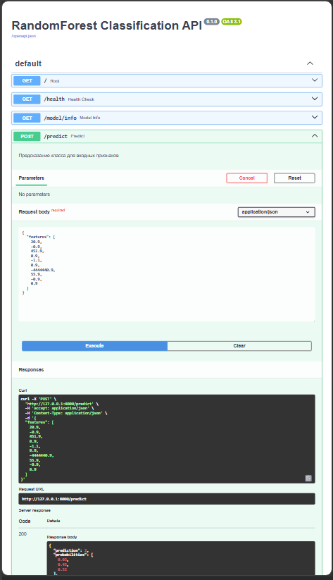

> ⚡ Define a goal → AI team designs, builds, and tests a working ML API

## 🌟 Overview

**AI Digital Office** is a multi-agent system where AI roles collaborate like a real engineering team to:

- 🏗️ Design architecture
- 📊 Train ML models
- ⚙️ Build APIs
- 🧪 Run tests

All you do is describe the task — the system does the rest.

## 🧠 System Architecture

```
                ┌───────────────┐
                │   USER GOAL   │
                └──────┬────────┘
                       │
                       ▼
        ┌────────────────────────────┐
        │      ORCHESTRATOR          │
        │       run_office()         │
        └──────────┬─────────────────┘
                   │
     ┌─────────────┼─────────────────────────────┐
     ▼             ▼             ▼               ▼
┌──────────┐ ┌────────────┐ ┌────────────┐ ┌────────────┐
│Architect │ │DataScientis│ │ML Engineer │ │QA Specialis│
└────┬─────┘ └─────┬──────┘ └─────┬──────┘ └─────┬──────┘
     │             │              │              │
     └─────────────┴──────────────┴──────────────┘
                        │
                        ▼
              🧾 Shared Memory (Journal)
```

## 👥 AI Roles

| Role | Description |
| --- | --- |
| 🏗️ Architect | Designs system structure & APIs |
| 📊 Data Scientist | Trains and saves ML models |
| ⚙️ ML Engineer | Integrates model into FastAPI |
| 🧪 QA Specialist | Tests API & validates outputs |

## 🧰 Tooling System

Agents interact using structured commands:

### 📁 File System

```
[WRITE_FILE: app/main.py]
# code
[END_WRITE]

[READ_FILE: app/main.py]
```

### 💻 Terminal

```
dir
pytest
uvicorn app.main:app --reload
```

✔ Windows-compatible ✔ Output captured into memory

## 🧾 Memory System

All actions are logged:

```
{
  "sender": "Architect",
  "message": "Created API structure",
  "output": "File app/main.py written"
}
```

👉 Enables:

- context awareness
- iterative improvements
- full traceability

## 🔄 Workflow

```
User Goal
   ↓
Architect → Data Scientist → ML Engineer → QA
   ↓
Tool Execution
   ↓
Memory Update
   ↓
Next Agent
   ↓
MISSION_COMPLETE 🎉
```

## ⚡ Example

### Input:

```
Build a modular ML API with /predict endpoint and tests
```

### Output:

✅ FastAPI app ✅ Trained model (.joblib) ✅ Working endpoint ✅ Passing tests

## 📂 Project Structure

```
project/
│
├── app/
│   ├── main.py
│   ├── api/
│   │   └── ml_router.py
│   └── core/
│       └── config.py
│
├── tests/
│   └── test_main.py
│
└── data/
    └── team_journal.json
```

## 🚀 Quick Start

### 1. Install

```
pip install litellm python-dotenv
```

### 2. Setup env

```
env
DEEPSEEK_API_KEY=your_key_here
```

### 3. Run

```
python main.py
```

## 💡 Features

✨ Multi-agent collaboration 🧠 Shared persistent memory 🛠️ Tool-augmented LLM agents 🔄 Autonomous execution loop ⚡ Rapid ML service prototyping

## ⚠️ Limitations

- No sandboxed execution
- Limited output validation
- Sequential workflow

## 🛣️ Roadmap

- 🔍 Reviewer / Critic agent
- 🔐 Secure execution sandbox
- 📊 Task planning (DAG)
- 🔁 Self-healing loops
- ☁️ Cloud deployment

## 🧠 Why This Project Matters

We are moving from:

> Writing code → Designing AI systems that write code

This project is a prototype of an **autonomous AI engineering team**.

## 🤝 Contributing

PRs welcome! Ideas:

- better prompts
- safety improvements
- evaluation metrics

## ⭐ Star This Repo

If you find this interesting, give it a ⭐ — it helps a lot!

## 3) 📝 [TEST-passer](https://github.com/UzunDemir/AI_test_helper)

### AI-Powered Test Assistant

[figure not shown]

## ✨ Overview

**TEST-passer** is an intelligent RAG (Retrieval-Augmented Generation) system that answers questions strictly based on uploaded educational materials. Perfect for students, educators, and professionals preparing for tests and exams.

## 🚀 Key Features

- **📄 PDF Upload** – Upload any educational PDF materials
- **🔍 Hybrid Search** – Combines semantic (FAISS) + keyword (TF-IDF) retrieval
- **🎯 HyDE Query Expansion** – Improves search relevance using AI-generated context
- **⚡ Cross-Encoder Reranking** – Prioritizes the most relevant chunks
- **💬 Strict Context** – Answers only from uploaded materials, no hallucinations
- **📚 Source Citations** – Shows document name and page numbers for each answer

## 🛠️ Tech Stack

| Component | Technology |
| --- | --- |
| **Embeddings** | SentenceTransformers (all-MiniLM-L6-v2) |
| **Vector DB** | FAISS (Facebook AI Similarity Search) |
| **Reranking** | Cross-Encoder (ms-marco-MiniLM-L-6-v2) |
| **LLM** | DeepSeek Chat API |
| **Frontend** | Streamlit |
| **PDF Processing** | PyPDF2 |

## 🧠 How It Works

[output not shown]

## 🔑 Environment Variables

Create `.streamlit/secrets.toml`:

```
DEEPSEEK_API_KEY = "sk-xxxxxxxxxxxxxxxxxxxxxxxx"
```

## 🎮 Usage

1. Launch the app
2. Upload one or more PDF files
3. Ask questions in natural language
4. Receive answers with source citations

## 📊 Example

**User:** *What is the capital of France?*

**Assistant:** According to *Geography.pdf* (page 12), Paris is the capital of France. It has been the political and cultural center since the 12th century.

## 🧩 Project Structure

```
test-passer/
├── app.py              # Main Streamlit application
├── requirements.txt    # Python dependencies
├── .streamlit/
│   └── secrets.toml    # API keys (gitignored)
└── README.md           # This file
```

## 🤝 Contributing

PRs and suggestions are welcome! Feel free to open an issue.

## 📄 License

MIT License — free to use, modify, and distribute.

⭐ **Star this repo** if you find it useful!

## 🤖 [AI HR-Recruiter](https://github.com/UzunDemir/maib_reqruiter)

**Intelligent recruitment system with automated CV analysis, interviews, and candidate evaluation**

[figure not shown]

## ✨ Features

| Module | Description |
| --- | --- |
| **📥 Vacancy Loading** | Automatic scraping of job vacancies from MAIB career portal with parallel processing |
| **📄 CV Analysis** | Upload CV (PDF/DOCX/TXT) — TF-IDF based matching with job descriptions |
| **🎯 Smart Matching** | Top-3 job recommendations with similarity scores and visual progress bars |
| **📊 Detailed Analysis** | AI-powered compatibility report: strengths, gaps, recommendations, match percentage |
| **🗣️ General Interview** | Dynamic question generation based on CV + AI response analysis (human vs AI detection) |
| **💻 Technical Interview** | Role-specific technical questions with automated scoring and feedback |
| **📑 Candidate Profile** | Structured profile generation: skills, experience, motivation, salary expectations |
| **✅ Final Decision** | Automated recommendation: hire / hire with reserves / reject with reasoning |
| **🌍 Multi-language** | UI in **Română / Русский / English** |

## 🏗️ Architecture Overview

```
┌─────────────────────────────────────────────────────────────────┐
│                    STREAMLIT FRONTEND                           │
├─────────────────────────────────────────────────────────────────┤
│  Sidebar (Lang / Steps / Vacancies)  │  Main Panel              │
├─────────────────────────────────────────────────────────────────┤
│                    ORCHESTRATION LAYER                          │
├─────────────────────────────────────────────────────────────────┤
│  ┌──────────┐ ┌──────────┐ ┌──────────┐ ┌──────────┐            │
│  │ Vacancy  │ │   CV     │ │ Matching │ │Interview │            │
│  │ Loader   │ │ Processor│ │ Engine   │ │ Manager  │            │
│  └──────────┘ └──────────┘ └──────────┘ └──────────┘            │
├─────────────────────────────────────────────────────────────────┤
│                      DEEPSEEK LLM API                           │
│  • Question generation  • Analysis  • Feedback  • Detection     │
├─────────────────────────────────────────────────────────────────┤
│                    DATA LAYER                                   │
│  ┌──────────┐ ┌──────────┐ ┌──────────┐ ┌──────────┐            │
│  │  PDF/    │ │   TF-IDF │ │ Session  │ │   DOCX   │            │
│  │  DOCX    │ │  Vector  │ │  State   │ │  Export  │            │
│  └──────────┘ └──────────┘ └──────────┘ └──────────┘            │
└─────────────────────────────────────────────────────────────────┘
```

## 🚀 Quick Start

### 1. Clone & Install

```
git clone https://github.com/your-repo/ai-hr-recruiter.git
cd ai-hr-recruiter
pip install -r requirements.txt
```

### 2. Configure API Key

Create `.streamlit/secrets.toml`:

```
DEEPSEEK_API_KEY = "your-api-key-here"
```

### 3. Run Application

```
streamlit run app.py
```

## 📁 Project Structure

```
ai-hr-recruiter/
├── app.py                    # Main application
├── requirements.txt          # Dependencies
├── .streamlit/
│   └── secrets.toml          # API keys (not in repo)
└── README.md
```

## 🔧 Tech Stack

| Component | Technology |
| --- | --- |
| Frontend | Streamlit |
| LLM | DeepSeek API |
| Document Parsing | PyPDF2, python-docx |
| Text Processing | scikit-learn (TF-IDF, cosine similarity) |
| Web Scraping | BeautifulSoup, requests |
| Parallel Processing | ThreadPoolExecutor |
| Export | python-docx |

## 🧠 Agent Workflow

```
1. Load Vacancies → 2. Upload CV → 3. Match Analysis →
4. General Interview → 5. Technical Interview → 6. Final Recommendation
```

Each step is saved in `st.session_state` — process can be resumed anytime.

## 📊 Sample Outputs

- **Match Analysis**: Strength/weakness breakdown + % match
- **Candidate Profile**: Professional portrait, motivation, salary expectations
- **Technical Feedback**: Detailed evaluation + score (0–10)
- **Final Report**: Complete DOCX with all stages

## ⚠️ Important Notes

- Vacancy source: `rabota.md` (MAIB company page) — URL may need updating
- LLM responses may vary; human oversight recommended for final decisions
- AI-generated answer detection is experimental

## 🔮 Future Improvements

- Persistent database for candidates
- Email notifications
- Video interview integration
- More sophisticated anti-cheating
- Docker deployment

## 👨‍💻 Author

**Uzun Demir**

## 📄 License

MIT